# Test 5. Spectum,Kepstrum

#### 2. Выборка Series3.

Провести спектральный анализ ряда. Построить периодограмму и провести сглаживание с помощью 3-х кратной свертки окна Даниэля. Оценить стандарное отклонение периодограммы и сглаженной периодограммы.

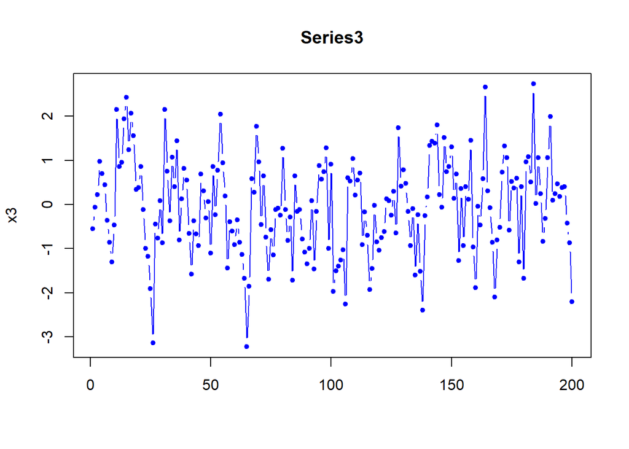

```r
x3 <- data[,3]
matplot(x3,type='b',main='Series3',pch=20,col='blue')
```

Оценим периодограмму

(Skipped Code)

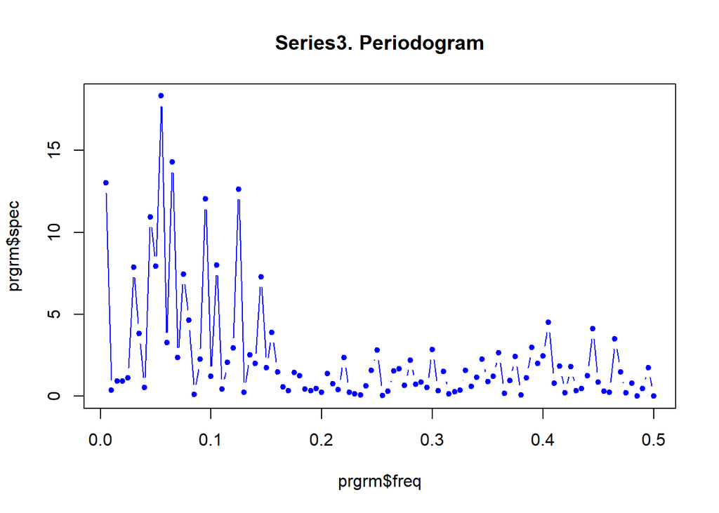

```r
prgrm<- periodogram(x3, col = "blue",lwd = 3,plot = FALSE)
plot(prgrm$freq,prgrm$spec,main = "Series3. Periodogram", type = 'b',pch = 20, col='blue')
```

Вычислим стандарное отклонение периодограммы

```r
(sd_prgrm<- sd(prgrm$spec))
```

```
## [1] 3.393864
```

Оценим сглаженную периодограмму методом spec.pgram() по 3-х кратной свертке окна Даниеля. Ширина окна равна 7.

(Skipped Code)

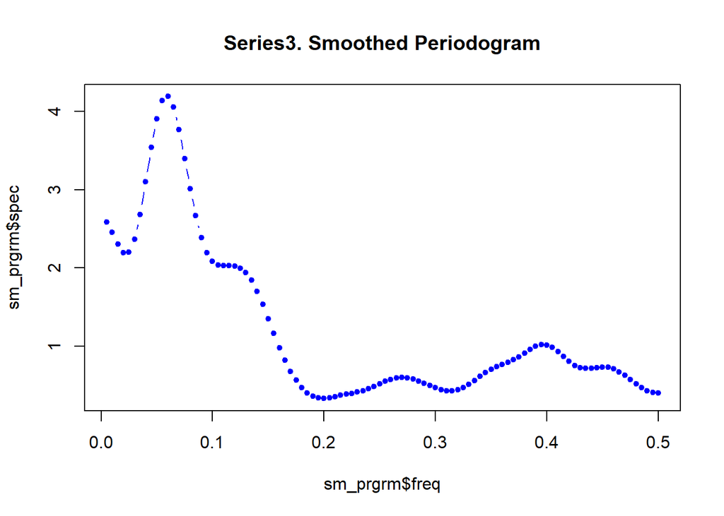

```r
sm_prgrm <-spec.pgram(x3,c(7,7,7),plot=FALSE)
plot(sm_prgrm$freq,sm_prgrm$spec,type = 'b',pch = 20,main = "Series3. Smoothed Periodogram",col='blue')
```

Вычислим стандарное отклонение сглаженной периодограммы

```r
(sd_sm_prgrm<- sd(sm_prgrm$spec))
```

```
## [1] 1.021878
```

На одном графике они будут выглядеть так

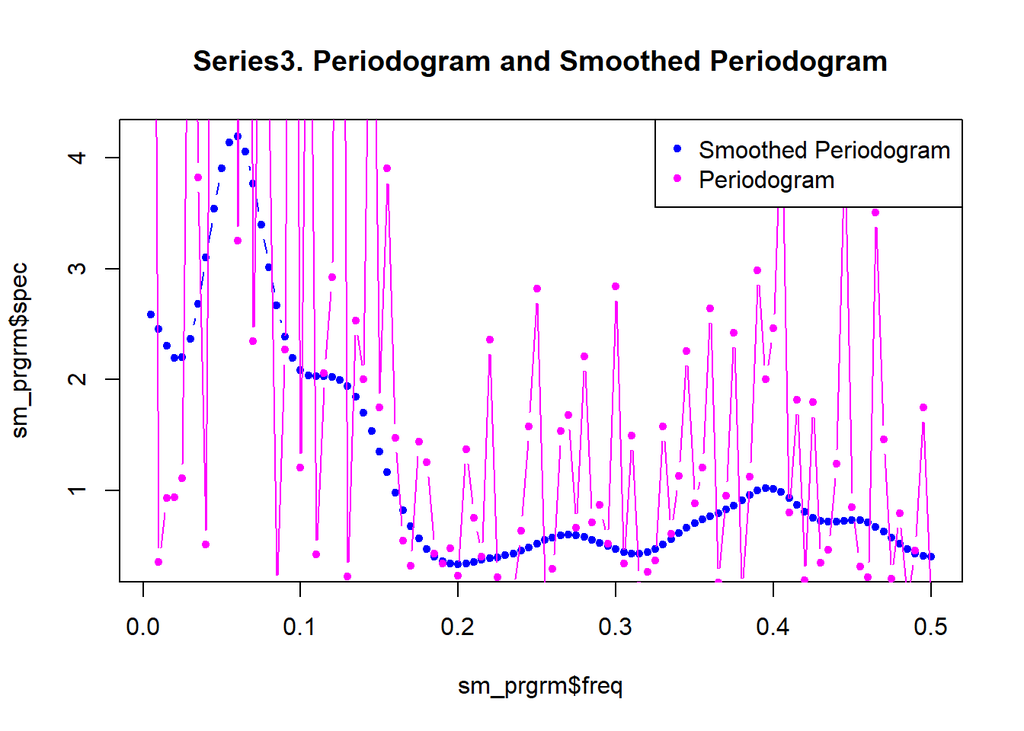

```r
plot(sm_prgrm$freq,sm_prgrm$spec,type = 'b',pch = 20,main = "Series3. Periodogram and Smoothed Periodogram",col='blue')
lines(prgrm$freq,prgrm$spec, type = 'b',pch = 20, col='Magenta')
legend("topright",legend= c("Smoothed Periodogram","Periodogram"),col = c("blue","magenta"),pch = 20)
```

Ответ :

## Проверка результатов

#### Series1

Вводить будете сначала большую частоту, потом меньшую.

#### Series3

Запустите шайни для проверки теста по ссылке https://shiny.ilykei.com/ANDoynikov/Tests_Prac/test5/

Установите свой номер своего варианта. Номер варианта это порядковый номер в журнале

Введите в шайни результаты и нажмите кнопку Submit

Получим следующие результаты Test result [,1]  
[1,] “1. Period 1: 10 /10”  
[2,] “1. Period 2: 10 /10”  
[3,] “2. Delay Number: 15 /15”  
[4,] “2. Kepstrum Value: 15 /15”  
[5,] “3. Std.dev. of periodogram: 25 /25”  
[6,] “3. Std.dev. of smooted spectral dencity: 25 /25” [7,] “Total score: 100 /100”

Результат 100 баллов из 100 возможных. Тест выполнен

Вы можете установить вариант 0 и ввести для тренировки эти результаты и убедится, что результат будет 100, но запишется результат не в Ваш номер.

Как считает Python не проверял, но любители Python пусть сначала повторят мои результаты на 0 варианте.

Результаты Вашего варианта сохранятся в некоторый недоступный Вам файл. Сохраняются только результаты последней попытки. Число попыток не ограничено.

Мне присылать ничего не надо. У меня есть воможность посмотреть Ваши результаты.